# Negative Binomial GLM Pseudo-R<sup>2</sup>

Brian J. Smith

2022-10-09

## Introduction

Pseudo-R<sup>2</sup> metrics for GLMs are analogous to ordinary R<sup>2</sup> for a linear regression model. As such, they are typically used as a measure of goodness-of-fit, with many users implicitly assuming that a low pseudo-R<sup>2</sup> corresponds to missing covariates and a poorly calibrated model.

The purpose of this document is to demonstrate via simulation a negative binomial GLM with high dispersion will have a low pseudo-R<sup>2</sup>, even if the model structure is 100% correct and the parameters are estimated well.

## Load packages

We will use the `MASS` package to fit the negative binomial GLM and the `MuMIn` package to calculate the pseudo-R<sup>2</sup>. We will use `ggplot2` to visualize the results

```r
library(MASS)
library(MuMIn)
library(ggplot2)
```

## Simulate data

We will simulate data under a very simple model. We’ll have just a single covariate, such that the linear predictor is just an intercept and a single slope, and we’ll use the natural logarithm as the link function.

$$log(\mu_i) = \beta_0 + \beta_1 x_{1,
i}$$

### Model parameters

Here are the true intercept and slope:

```r
b0 <- 0.5
b1 <- -1
```

And some random values of $x_1$:

```r
set.seed(123456)
x1 <- rnorm(n = 1000, mean = 0, sd = 1)
```

Now we construct the linear predictor.

```r
# Link scale
log_mu <- b0 + b1 * x1

# Natural scale
mu <- exp(log_mu)
```

### Simulate response data

We’ll simulate three data sets with the same linear predictor:

1. using the Poisson (no overdispersion),
2. using the negative binomial (moderate overdispersion),
3. using the negative binomial (strong overdispersion).

The negative binomial is parameterized in terms of a size ($r$) and probability ($p$) parameter. In order to use it as an overdispersed Poisson, we can fix $r$ (smaller $r$ means greater dispersion) and then calculate $p$ as:

$$p_i = \frac{r}{r + \mu_i}$$

Note that $p_i$ and $\mu_i$ have an observation-level subscript ($i$), but $r$ does not.

The variance around the expected value ($\mu_i$) for the negative binomial is then:

$$\sigma^2_i =
\frac{(1-p_i)r}{p_i^2}$$

```r
# 1. Poisson
y_pois <- rpois(n = length(mu), lambda = mu)

# 2. Negative binomial (moderate overdispersion)
r1 <- 0.5
p1 <- r1/(r1 + mu)
y_nb1 <- rnbinom(n = length(mu), size = r1, prob = p1)

# 3. Negative binomial (strong overdispersion)
r2 <- 0.05
p2 <- r2/(r2 + mu)
y_nb2 <- rnbinom(n = length(mu), size = r2, prob = p2)
```

We can take a quick look at histograms of our results. Remember that the expected value is the same for all observations in all 3 datasets.

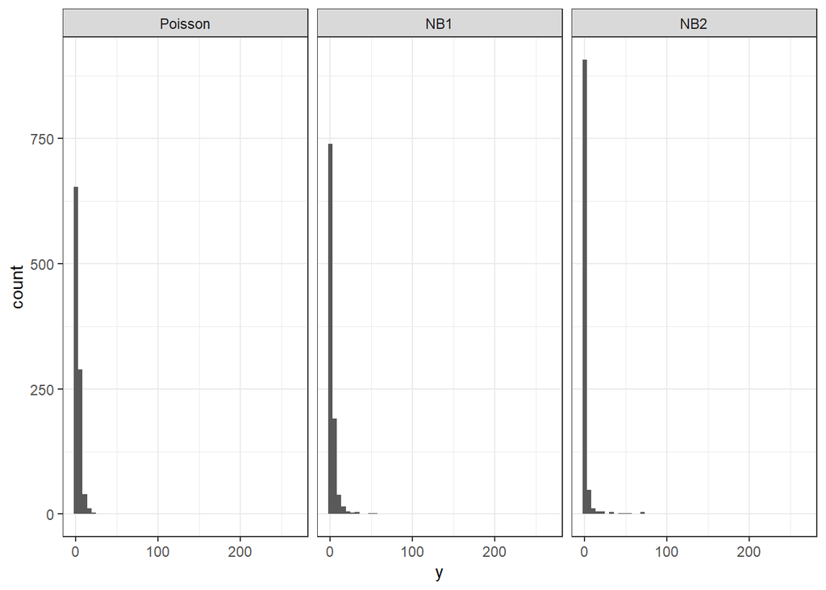

```r
# Combine datasets
y <- rbind(
  data.frame(which = "Poisson", y = y_pois),
  data.frame(which = "NB1", y = y_nb1),
  data.frame(which = "NB2", y = y_nb2)
)
# Factor 'which' with desired plotting order
y$which <- factor(y$which, levels = c("Poisson", "NB1", "NB2"))

# Plot
ggplot(y, aes(x = y)) +
  facet_wrap(~ which) +
  geom_histogram(bins = 50) +
  theme_bw()
```

You can see that as we increase the variance from left to right, we both increase the number of 0s and the number of large values.

## Fit models

Now we will fit the appropriate model to each of our simulated datasets.

```r
# 1. Poisson
m1 <- glm(y_pois ~ x1, family = poisson())

# 2. Negative binomial (moderate overdispersion)
m2 <- glm.nb(y_nb1 ~ x1)

# 3. Negative binomial (strong overdispersion)
m3 <- glm.nb(y_nb2 ~ x1)
```

## Compare model fit

Let’s demonstrate that we were able to estimate the parameters well in each model.

```r
# 1. Poisson
betas1 <- coef(m1)
ci1 <- confint(m1)
# 2. Negative binomial (moderate overdispersion)
betas2 <- coef(m2)
ci2 <- confint(m2)
# 3. Negative binomial (strong overdispersion)
betas3 <- coef(m3)
ci3 <- confint(m3)
```

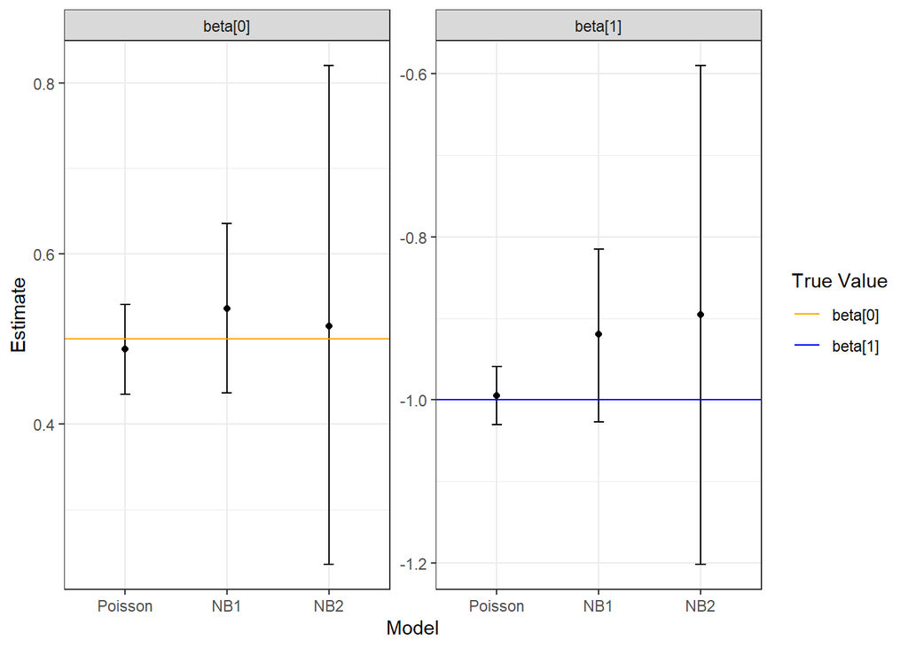

```r
# Combine
beta_data <- rbind(
  data.frame(which = "Poisson",
             parm = c("beta[0]", "beta[1]"),
             lwr = ci1[, 1],
             est = betas1,
             upr = ci1[, 2],
             true = c(b0, b1)),
  data.frame(which = "NB1",
             parm = c("beta[0]", "beta[1]"),
             lwr = ci2[, 1],
             est = betas2,
             upr = ci2[, 2],
             true = c(b0, b1)),
  data.frame(which = "NB2",
             parm = c("beta[0]", "beta[1]"),
             lwr = ci3[, 1],
             est = betas3,
             upr = ci3[, 2],
             true = c(b0, b1))
)
# Factor 'which' with desired plotting order
beta_data$which <- factor(beta_data$which, levels = c("Poisson", "NB1", "NB2"))

# Plot
ggplot(beta_data, aes(x = which, y = est, ymin = lwr, ymax = upr, grup = which)) +
  facet_wrap(~ parm, scales = "free_y") +
  geom_errorbar(width = 0.1) +
  geom_hline(aes(yintercept = true, color = factor(true))) +
  geom_point() +
  xlab("Model") +
  ylab("Estimate") +
  scale_color_manual(name = "True Value", breaks = c(b0, b1),
                     labels = c("beta[0]", "beta[1]"),
                     values = c("orange", "blue")) +
  theme_bw()
```

We can see that all 3 models estimated both $\beta_0$ and $\beta_1$ with enough precision and accuracy that the true values (horizontal lines) are always captured within the 95% confidence interval.

## Compare pseudo-R<sup>2</sup>

Our models have performed well, recovering the true parameter values in each case. How do their pseudo-R<sup>2</sup>s compare?

```r
# Calculate pseudo-R^2
suppressWarnings({
  r2_1 <- r.squaredGLMM(m1)[1, 1]
  r2_2 <- r.squaredGLMM(m2)[1, 1]
  r2_3 <- r.squaredGLMM(m3)[1, 1]
})
```

| Model | Pseudo-R<sup>2</sup> |
| --- | --- |
| Poisson | 0.722 |
| NB1 | 0.279 |
| NB2 | 0.035 |

We can see that the Poisson model has a “high” pseudo-R<sup>2</sup> of about 0.72. Most users would be relatively happy with this metric. The moderately overdispersed negative binomial (NB1) has a much lower pseudo-R<sup>2</sup> of just 0.28. Most users would likely still accept this value, but they might be tempted to look for missing covariates (even though our model is perfectly specified). The strongly overdispersed negative binomial (NB2) is the most concerning. It has pseudo-R<sup>2</sup> of just 0.04, even though the model was specified exactly correctly and the model estimated the parameters with good accuracy and precision.

## Conclusion

Even for a correctly specified and well estimated model, a negative binomial GLM will still have a low pseudo-R<sup>2</sup>. Accounting for overdispersion is important for accurately estimating parameters and avoiding overfitting. If the negative binomial model is justifiable from first principles, you may not want to put too much weight behind a low pseudo-R<sup>2</sup>. After all, you asked the model to have overdispersion when you chose the NB over the Poisson.

This page was created in RMarkdown and is hosted on GitHub. See the source code in the GitHub repository here: https://github.com/bsmity13/negbin_R2